# STOR 320 Tutorial on Exploratory Data Analysis

Mario Giacomazzo

June 27, 2019

# Introduction

Consider the dataset `Wages1` from the `Ecdat` package.

```
##   exper    sex school     wage
## 1     9 female     13 6.315296
## 2    12 female     12 5.479770
## 3    11 female     11 3.642170
## 4     9 female     14 4.593337
## 5     8 female     14 2.418157
## 6     9 female     14 2.094058
```

This observational dataset records the years experienced, the years schooled, the sex, and the hourly wage for 3,294 workers in 1987. *A Guide to Modern Econometrics* by Marno Verbeek utilizes this data in a linear regression context. According to Marno Verbeek, this data is a subsample from the US National Longitudinal Study. The purpose of this tutorial is to practice the creative process in exploratory data analysis of asking questions and then investigating those questions using visuals and statistical summaries.

As a member of the birth class of 1988, I do not have any clue of what the workforce looked like in 1987. It is your job to apply your detective skills to the information hidden in this data. For future use, utilize the modified dataset`wage` according to the R code below:

```r
wage=as.tibble(Wages1) %>%
  rename(experience=exper) %>%
  arrange(school)
head(wage)
```

```
## # A tibble: 6 x 4
##   experience sex    school  wage
##        <int> <fct>   <int> <dbl>
## 1         18 male        3 5.52
## 2         15 male        4 3.56
## 3         18 male        4 9.10
## 4         10 female      5 0.603
## 5         11 male        5 3.80
## 6         14 male        5 7.50
```

# Part 1: Questions About Variation

### Question 1: What is the most common number of years of experience found in the data?

First, use `geom_bar()` to investigate the distribution of level of experience found in `wage`.

```r
#
```

Use `group_by(experience)` along with the pipe `%>%` to output the most common amount of years of experience along with the number of occurrences found in the data. The most common value for years of experience is _____ and occurs _____ times.

```r
wage %>%
  group_by(experience) %>%
  summarize(n=n()) %>%
  arrange(desc(n)) %>%
  summarize(common.exp=first(experience),common.n=first(n))
```

```
## # A tibble: 1 x 2
##   common.exp common.n
##        <int>    <int>
## 1          9      654
```

### Question 2: What is the maximum number for years of schooling found in the data?

First, use `geom_bar()` to visualize the overall distribution of level of schooling found in the data.

```r
#
```

Next, modify the code in Question 1 to display the maximum level of schooling and the number of workers in the data that had that number of schooling. The maximum number of years in school was ____ years which occurred _____ times in our sample

```r
#
```

### Follow-up to Questions 1-2: Are there outliers?

Based on the figures created using `geom_bar()` do there seem to be any outlying observations corresponding to levels of experience and/or levels of schooling outside the overall pattern seen within the variables `experience` and `school`. If outliers or potential errors exist, use `ifelse()` along with `mutate()` to replace these unusual values with `NA` in a new tibble called `wage.edit`. If not, then move on to the next set of questions pertaining to covariation.

```r
#
```

# Part 2: Questions about Covariation

### Follow-up to Questions 1-2: Is there a relationship between level of schooling and level of experience?

Use `geom_point()` to display a scatter plot representing the relationship between these two discrete numeric variables. Consider using `alpha=0.1` to indicate where the relationship is represented the best.

The years of experience seem to _____ (increase/decrease) as the years of schooling increases. Is this what you expected to see? ____ (yes/no). Practically, what reasons do you hypothesize for this observed relationship?

```r
#
```

### Question 3: How do hourly wages differ between males and females?

Use `geom_freqpoly()` to compare the distribution of wage of females to the distribution o fwage of males. Where do these distributions look the same and where do they differ.

```r
#
```

Use `group_by()` along with summarize to report the mean `wage`, standard error of `wage`, and 95% confidence interval for the unknown population mean hourly wage for the various levels of `sex`. The standard error is equal to the standard deviation divided by the square root of the sample size. The 95% confidence interval is approximated by obtaining the lower and upper bound of an interval within 2 standard errors of the sample mean. Based on the confidence limits, do we have statistical evidence to say that the average hourly wage for men was larger than the average hourly wage for women in 1987? ______ (yes/no). How would you explain your answer in terms of the confidence intervals that are constructed below?

```r
wage %>%
  group_by(sex) %>%
  summarize(n=n(),mean=mean(wage),se=sd(wage)/sqrt(n),
            lb=mean-2*se,ub=mean+2*se)
```

```
## # A tibble: 2 x 6
##   sex        n  mean     se    lb    ub
##   <fct>  <int> <dbl>  <dbl> <dbl> <dbl>
## 1 female  1569  5.15 0.0726  5.00  5.29
## 2 male    1725  6.31 0.0842  6.14  6.48
```

### Question 4: Does the relationship between hourly wage and years of experience differ between the sexes?

Use `geom_point()` along with the option `color=sex` to overlay scatter plots. Does there seem to be a clear distinction between female and male regarding this relationship? ______ (yes/no).

```r
#
```

### Question 5: Does the relationship between hourly wage and years of schooling differ between the sexes?

Repeat the graphic created in Question 4 replacing `x=experience` with `x=school`. Does there seem to be a clear distinction between female and male regarding this relationship? ______ (yes/no).

```r
#
```

### Question 6: What is the relationship between hourly wage and the interaction between the years of experience and years of schooling?

The graphic below summarizes the average hourly wage for the different combinations of schooling and experience level. The additional `facet_grid(~sex)` makes comparing the relationship of the three key numeric variables between the sexes quite easy. What are some differences between the sexes regarding this relationship that are apparent in this chart?

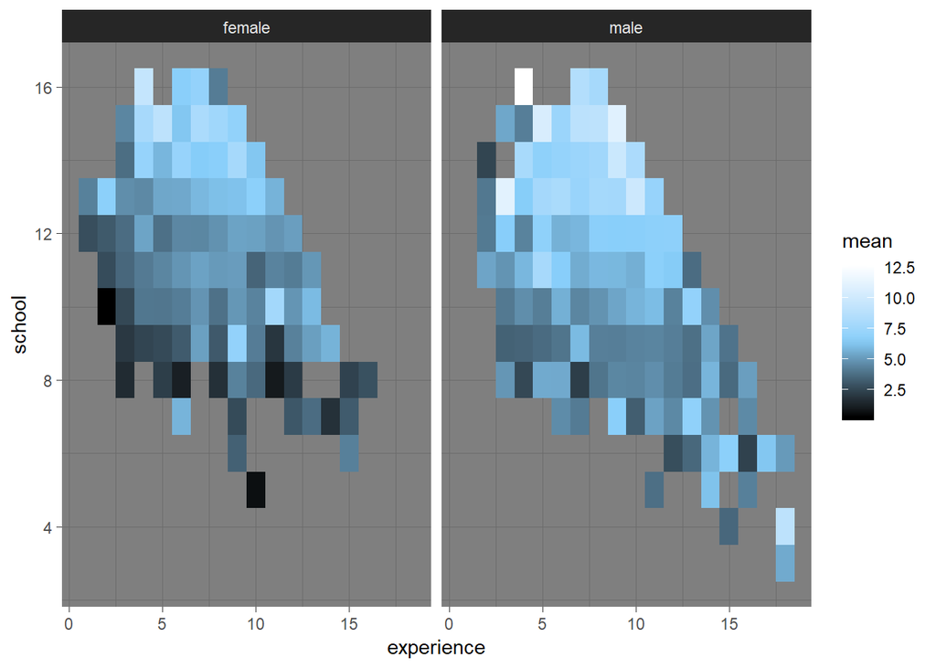

```r
wage %>%
  group_by(experience,school,sex) %>%
  summarize(n=n(),mean=mean(wage)) %>%
  ungroup() %>%
  ggplot() +
    geom_tile(aes(x=experience,y=school,fill=mean)) +
  scale_fill_gradientn(colors=c("black","lightskyblue","white"))+
    facet_grid(~sex) + theme_dark()
```

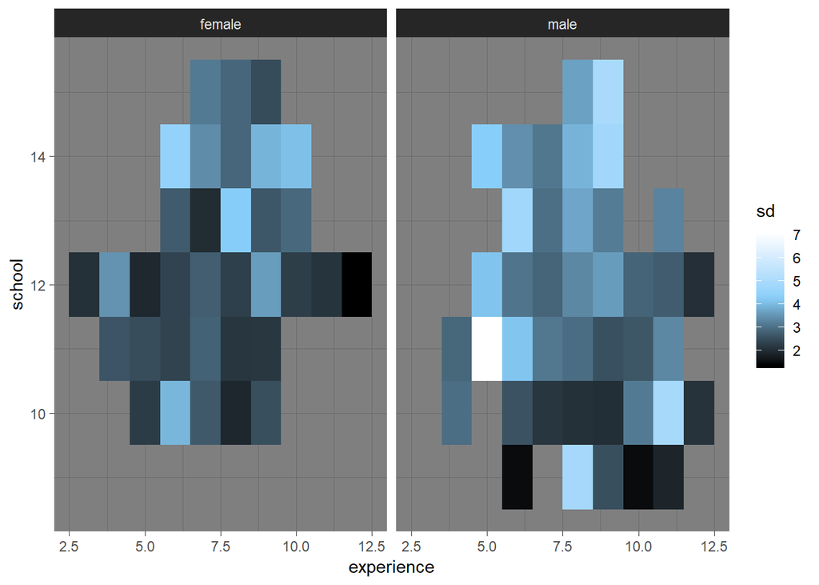

```r
wage %>%
  group_by(experience,school,sex) %>%
  summarize(n=n(),sd=sd(wage)) %>%
  ungroup() %>%
  filter(n>10) %>%
  ggplot() +
  geom_tile(aes(x=experience,y=school,fill=sd)) +
  scale_fill_gradientn(colors=c("black","lightskyblue","white"))+
  facet_grid(~sex) + theme_dark()
```